# This is just here so you can preview the styling on your local machine

#### Predicting Duration of Structures Developments

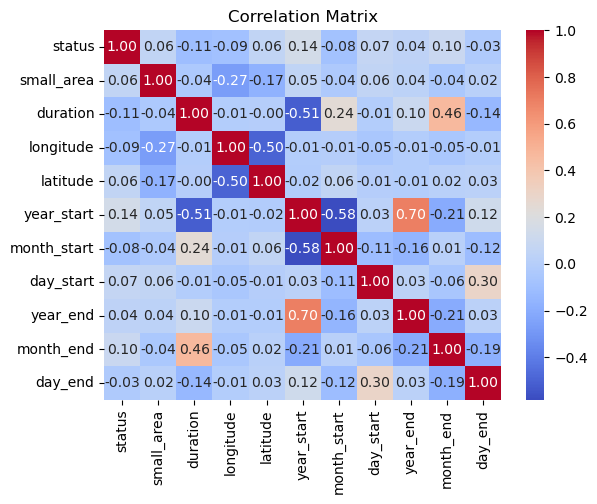

```python
# Get usable attributes
activities_encode = activities_structures.copy()
activities_encode = activities_encode[['classification', 'end_date', 'start_date', 'status', 'small_area', 'duration',
                                       'longitude', 'latitude']]

# Split date to day, month, year
activities_encode['year_start'] = activities_encode['start_date'].dt.year
activities_encode['month_start'] = activities_encode['start_date'].dt.month
activities_encode['day_start'] = activities_encode['start_date'].dt.day
activities_encode['year_end'] = activities_encode['end_date'].dt.year
activities_encode['month_end'] = activities_encode['end_date'].dt.month
activities_encode['day_end'] = activities_encode['end_date'].dt.day

# Label encode all four columns
label_encoder = LabelEncoder()
for col in ['status', 'small_area']:
    activities_encode[f'{col}'] = label_encoder.fit_transform(activities_encode[col])

# Calculate the correlation matrix
correlation_matrix = activities_encode.corr()

# Plot the correlation matrix using a heatmap
sns.heatmap(correlation_matrix, annot=True, cmap='coolwarm', fmt=".2f")
plt.title("Correlation Matrix")
plt.show()
```

```python
# Selecting the features and target variable
X = activities_encode[['year_start', 'month_start', 'longitude', 'latitude']]
y = activities_encode['duration']

# Splitting the data into training and testing sets
X_train, X_test, y_train, y_test = train_test_split(X, y, test_size=0.2, random_state=42)

# Standardize features if needed
scaler = StandardScaler()
X_train_scaled = scaler.fit_transform(X_train)
X_test_scaled = scaler.transform(X_test)

# Initialize the RandomForestRegressor
model = RandomForestRegressor()

# Train the model
model.fit(X_train_scaled, y_train)

# Make predictions on the test set
y_pred = model.predict(X_test_scaled)

# Evaluate the model
mse = mean_squared_error(y_test, y_pred)
r2 = r2_score(y_test, y_pred)

# Print the evaluation metrics
print(f'Mean Squared Error: {mse}')
print(f'R-squared: {r2}')

# Function to get user input and make predictions
def predict_duration():
    # Get user input
    year_start = float(input("Enter Year Started of Development: "))
    month_start = float(input("Enter Month Started of Development: "))
    longitude = float(input("Enter Longitdue: "))
    latitude = float(input("Enter Latitude: "))

    # Prepare input for prediction
    user_input = [[year_start, month_start, longitude, latitude]]

    # Standardize the input features using the same scaler
    user_input_scaled = scaler.transform(user_input)

    # Make predictions
    predicted_duration = model.predict(user_input_scaled)[0]

    # Print the result
    print(f'Predicted Duration of Development: {predicted_duration} days')

# Call the function

predict_duration()
```

```
Mean Squared Error: 7683.609901425628
R-squared: 0.6204076953569291
```

```
Predicted Duration of Development: 466.62 days
```

## Part 2.3: Traffic Managment Analysis

#### Combine Events & Remove

Activities Dataset, Combine Events & remove structure attribute

Traffic Management had the most datacollection (85 elements), Followed by Reserved Parking (69 elements) and Combined Events (32 elements).

- Traffic Management 45.7%
- Reserved Parking 37.1%
- Combined Events 17.2%

```
Number of occurrences for each classification in Activities:
Structures            415
Traffic Management     85
Reserved Parking       69
Event                  17
Public Event           14
Private Event           1
Name: classification, dtype: int64
――――――――――
Number of occurrences for each classification in Activities:
Structures            415
Traffic Management     85
Reserved Parking       69
Combined Events        32
Name: combined_event_type, dtype: int64
――――――――――
```

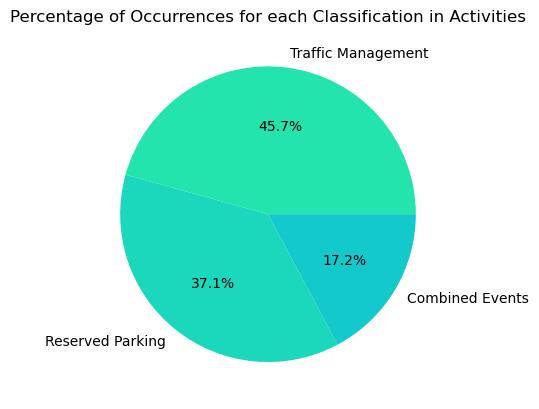

```python
# Unique elements in classification attribute activities
unique_classifications = activities['classification'].unique()
classification_counts = activities['classification'].value_counts()

print("Number of occurrences for each classification in Activities:")
print(classification_counts)

print('―' * 10)

# Combine events
activities['combined_event_type'] = activities['classification'].replace(['Event', 'Public Event', 'Private Event'], 'Combined Events')

# Print the count of each unique classification in activities
classification_counts = activities['combined_event_type'].value_counts()

print("Number of occurrences for each classification in Activities:")
print(classification_counts)

print('―' * 10)

activities['combined_event_type'] = activities['classification'].replace(['Event', 'Public Event', 'Private Event'], 'Combined Events')

# Filter for specific classifications & removed 'Structures' to focus on traffic
selected_classifications = ['Traffic Management', 'Reserved Parking', 'Combined Events']
filtered_activities = activities[activities['combined_event_type'].isin(selected_classifications)]

filtered_activities['combined_event_type'].value_counts().plot.pie(autopct='%1.1f%%', colors=[light_theme_colors[1], light_theme_colors[2], light_theme_colors[3]])
plt.title('Percentage of Occurrences for each Classification in Activities')
plt.ylabel('')
plt.show()
```

#### Mean, Max and Min (Distribution)

Mean, Max and Min Activity Distribution Activities (Traffic Management, Reserved Parking, Combined Events)

The following is observed for traffic management, reserved parking and combined events in Activities dataset.**

**Total**

These numbers represent the total count of activities recorded across all years.

- Traffic Management 85
- Reserved Parking 69
- Combined Events 32

**Mean**

The mean provides the average level of activity, indicating the typical behavior for each type of activity.

- Traffic Management 14.17
- Reserved Parking 11.50
- Combined Events 5.33

**Max**

The maximum values represent the highest observed activity for each type, highlighting peak levels.

- Traffic Management 80
- Reserved Parking 69
- Combined Events 24

**Min**

The minimum values represent the lowest observed activity, demonstrating the range of the dataset.

- Traffic Management 0
- Reserved Parking 0
- Combined Events 1

**Observations**

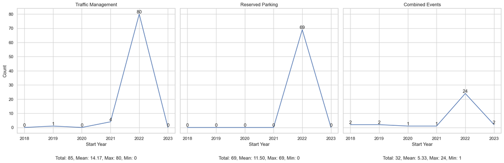

```
Classification: Traffic Management
Year 2018: 0 elements
Year 2019: 1 elements
Year 2020: 0 elements
Year 2021: 4 elements
Year 2022: 80 elements
Year 2023: 0 elements

Classification: Reserved Parking
Year 2018: 0 elements
Year 2019: 0 elements
Year 2020: 0 elements
Year 2021: 0 elements
Year 2022: 69 elements
Year 2023: 0 elements

Classification: Combined Events
Year 2018: 2 elements
Year 2019: 2 elements
Year 2020: 1 elements
Year 2021: 1 elements
Year 2022: 24 elements
Year 2023: 2 elements
```

```python
# Datetime format
activities['start_date'] = pd.to_datetime(activities['start_date'], errors='coerce')
activities['start_year'] = activities['start_date'].dt.year # Find year from start_date

# Filter
selected_classifications = ['Traffic Management', 'Reserved Parking', 'Combined Events']
filtered_activities = activities[activities['combined_event_type'].isin(selected_classifications)]

# Group data and combinations
grouped_data = filtered_activities.groupby(['start_year', 'combined_event_type']).size().reset_index(name='count')
all_combinations = pd.MultiIndex.from_product([grouped_data['start_year'].unique(), selected_classifications], names=['start_year', 'combined_event_type'])
grouped_data = grouped_data.set_index(['start_year', 'combined_event_type']).reindex(all_combinations, fill_value=0).reset_index()

# Plot
sns.set(style="whitegrid")

# Subplot Grid
fig, axes = plt.subplots(nrows=1, ncols=3, figsize=(18, 6), sharey=True)

# Classifications subplots
for i, classification in enumerate(selected_classifications):
    ax = axes[i]
    counts = grouped_data[grouped_data['combined_event_type'] == classification]
    sns.lineplot(x='start_year', y='count', data=counts, ax=ax)

    # Titles labels
    ax.set_title(classification)
    ax.set_xlabel('Start Year')
    ax.set_ylabel('Count')

    # Print counts
    for _, row in counts.iterrows():
        ax.text(row['start_year'], row['count'], str(row['count']), ha='center', va='bottom')

    # Print
    total_count = counts['count'].sum()
    mean_count = counts['count'].mean()
    max_count = counts['count'].max()
    min_count = counts['count'].min()
    stats_str = f"Total: {total_count}, Mean: {mean_count:.2f}, Max: {max_count}, Min: {min_count}"
    ax.text(0.5, -0.2, stats_str, transform=ax.transAxes, ha='center', va='center', bbox=dict(boxstyle='round', facecolor='white', alpha=0.7))

plt.tight_layout()
plt.show()

# Print elements for each year based on filter
data = ""

for classification in selected_classifications:
    data += f"\nClassification: {classification}\n"
    # Filter
    counts = grouped_data[grouped_data['combined_event_type'] == classification]

    # Iterate
    for _, row in counts.iterrows():
        year = int(row['start_year'])
        count = row['count']
        data += f"Year {year}: {count} elements\n" # Count

print(data)
```

#### Temporal Analysis (Monthly Distribution)

Activities Traffic Management, Reserved Parking, Combined Events

Overall highest periods of data records/ activity was January and May.

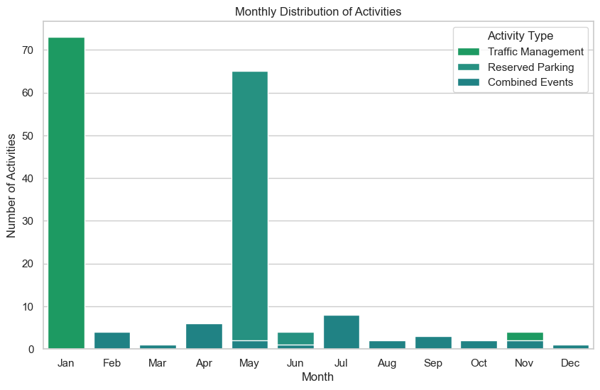

```
Traffic Management - 73, 1, 1, 1, 5, 0, 0, 0, 0, 0, 4, 0
Reserved Parking - 0, 0, 0, 0, 65, 4, 0, 0, 0, 0, 0, 0
Combined Events - 0, 4, 1, 6, 2, 1, 8, 2, 3, 2, 2, 1
```

```python
# Datetime, find month data
activities['start_date'] = pd.to_datetime(activities['start_date'])
activities['month'] = activities['start_date'].dt.month

# Filter
selected_classifications = ['Traffic Management', 'Reserved Parking', 'Combined Events']
filtered_activities = activities[activities['combined_event_type'].isin(selected_classifications)]

# Count number
monthly_activity_counts = filtered_activities.groupby(['month', 'combined_event_type']).size().unstack(fill_value=0)

# Plot
sns.set(style="whitegrid")
plt.figure(figsize=(10, 6))

activity_summary = []  # Store data

for classification, color in zip(selected_classifications, dark_theme_colors):
    sns.barplot(x=monthly_activity_counts.index, y=monthly_activity_counts[classification], label=classification, color=color)

    activity_summary.append(f"{classification} - {', '.join(str(val) for val in monthly_activity_counts[classification])}")


plt.xlabel('Month')
plt.ylabel('Number of Activities')
plt.title('Monthly Distribution of Activities')
plt.legend(title='Activity Type')
months = ["Jan", "Feb", "Mar", "Apr", "May", "Jun", "Jul", "Aug", "Sep", "Oct", "Nov", "Dec"]
plt.xticks(range(12), months)
plt.show()

# Print summary
print("\n".join(activity_summary))
```

#### Temporal Analysis (Yearly Distribution)

Activities Traffic Management, Reserved Parking, Combined Events

Aim is to find insights into the distribution of data records including mean durations for Traffic Management, Reserved Parking and Combined Events. There is a wide duration of mean suggesting potential differences in the characteristics of each activity type. The absence of data records is noteworthy and could be expored further to understand the reasons behind patterns.

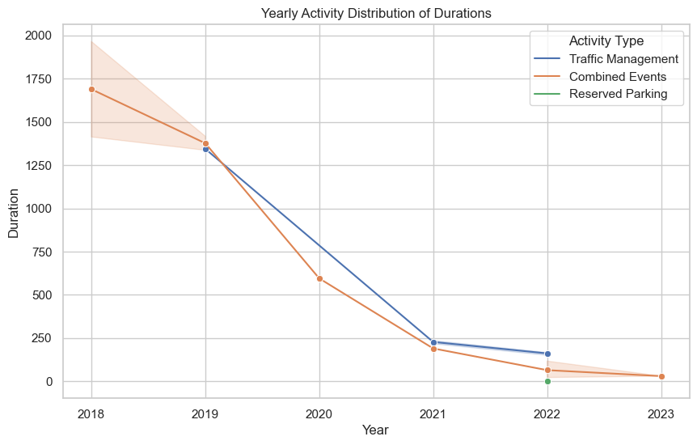

```
Classification: Traffic Management, Year: 2022, Data: 80 entries, Mean Duration: 161.30
Classification: Traffic Management, Year: 2021, Data: 4 entries, Mean Duration: 227.50
Classification: Traffic Management, Year: 2019, Data: 1 entries, Mean Duration: 1344.00
Classification: Reserved Parking, Year: 2022, Data: 69 entries, Mean Duration: 0.00
Classification: Combined Events, Year: 2018, Data: 2 entries, Mean Duration: 1689.00
Classification: Combined Events, Year: 2022, Data: 24 entries, Mean Duration: 64.54
Classification: Combined Events, Year: 2023, Data: 2 entries, Mean Duration: 30.00
Classification: Combined Events, Year: 2019, Data: 2 entries, Mean Duration: 1376.50
Classification: Combined Events, Year: 2020, Data: 1 entries, Mean Duration: 595.00
Classification: Combined Events, Year: 2021, Data: 1 entries, Mean Duration: 190.00
```

```python
# Temporal Analysis (Yearly Activity Distribution)
sns.set(style="whitegrid")
plt.figure(figsize=(10, 6))

activity_summary = [] # Store data
selected_classifications = ['Traffic Management', 'Reserved Parking', 'Combined Events']

# Find year
activities['start_date'] = pd.to_datetime(activities['start_date'])
activities['year'] = activities['start_date'].dt.year

# Filter
filtered_activities = activities[activities['combined_event_type'].isin(selected_classifications)]

# Add to string
for classification in selected_classifications:
    # Filter
    subset_data = filtered_activities[filtered_activities['combined_event_type'] == classification]
    for year in subset_data['year'].unique():
        year_data = subset_data[subset_data['year'] == year]
        mean_duration = year_data['duration'].mean()
        summary_str = f"Classification: {classification}, Year: {year}, Data: {len(year_data)} entries, Mean Duration: {mean_duration:.2f}"
        activity_summary.append(summary_str)

# # Plot
# sns.boxplot(x='year', y='duration', data=filtered_activities, hue='combined_event_type')
# plt.title('Box Plot of Activity Durations by Year')
# plt.xlabel('Year')
# plt.ylabel('Duration')
# plt.legend(title='Activity Type')
# plt.show()
# Line plot
sns.lineplot(x='year', y='duration', hue='combined_event_type', data=filtered_activities, marker='o')
plt.title('Yearly Activity Distribution of Durations')
plt.xlabel('Year')
plt.ylabel('Duration')
plt.legend(title='Activity Type')
plt.show()

# Print summary
print("\n".join(activity_summary))
```

#### Median Traffic Management Count for Each Year

Observations

- Half of the median count for Traffic Management 2019 is $1.0$, this suggests during this 2019 half of the months had an activity count of $< 1$, while the other proportion of the year activity count was $> 1$.
- Median count for Traffic Management 2021 is $4.0$, this suggests during this 2019 half of the months had an activity count of $< 4$, while the other proportion of the year activity count was $> 4$.
- Median count for Traffic Management 2022 is $3.0$, this suggests during this 2019 half of the months had an activity count of $< 3$, while the other proportion of the year activity count was $> 3$.

The highest median count (2021) indicates a higher central Traffic Mangement activity. However it is evident data collection is not consistant across these years due to varied differences in measures.

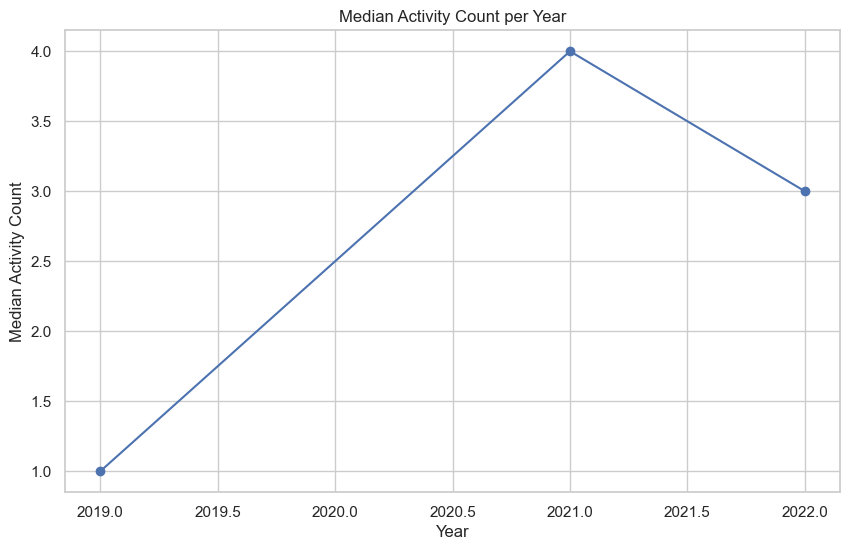

```
Year: 2019, Median Activity Count: 1.0
Year: 2021, Median Activity Count: 4.0
Year: 2022, Median Activity Count: 3.0
```

```python
# Median
sns.set(style="whitegrid")

# Define
selected_classifications = ['Traffic Management']

# Filter
filtered_activities = activities[activities['combined_event_type'].isin(selected_classifications)]

# Year and Date
filtered_activities['year'] = filtered_activities['start_date'].dt.year
filtered_activities['month'] = filtered_activities['start_date'].dt.month

# Dataframe
activities_count = filtered_activities.groupby(['year', 'month']).size().reset_index(name='activity_count')

# Reshape
activities_pivot = activities_count.pivot(index='year', columns='month', values='activity_count')

# Calculate yearly median
median_activity_per_year = activities_pivot.median(axis=1)

# Plot
median_activity_per_year.plot(kind='line', figsize=(10, 6), marker='o', linestyle='-', color='b')
plt.title('Median Activity Count per Year')
plt.xlabel('Year')
plt.ylabel('Median Activity Count')
plt.show()

# Summary
median_summary = []
for year, median_count in median_activity_per_year.items():
    median_summary.append(f"Year: {year}, Median Activity Count: {median_count}")

# Print
print("\n".join(median_summary))
```

### User Query

#### User can explore classifications:

- Structures
- Traffic Management
- Event
- Reserved Parking
- Public Event
- Private Event

```python
# Classifications
unique_classifications = activities['classification'].unique()

# User query
@interact(classification=widgets.Dropdown(options=unique_classifications, description='Select Classification:'))
def plot_monthly_distribution(classification):
    # Filter
    filtered_dataset = activities[activities['classification'] == classification]

    # Count per month
    monthly_counts = filtered_dataset['month_year'].value_counts().sort_index()

    # Plot
    plt.figure(figsize=(10, 6))
    sns.barplot(x=monthly_counts.index, y=monthly_counts.values, color=dark_theme_colors[1])
    plt.xlabel('Month')
    plt.ylabel(f'Number of {classification} per Month')
    plt.title(f'Monthly Distribution of {classification}')
    plt.xticks(rotation=45)
    plt.tight_layout()
    plt.show()
```

```
interactive(children=(Dropdown(description='Select Classification:', options=('Structures', 'Traffic Managemen…
```

#### Spatial Analysis All Activities

Prints all activities in dataset to folium map.

- Structures
- Traffic Management
- Event
- Reserved Parking
- Public Event
- Private Event

Note: available folium icon colors are ‘red’, ‘blue’, ‘green’, ‘purple’, ‘orange’, ‘darkred’, ‘lightred’, ‘beige’, ‘darkblue’, ‘darkgreen’, ‘cadetblue’, ‘darkpurple’, ‘white’, ‘pink’, ‘lightblue’, ‘lightgreen’, ‘gray’, ‘black’, ‘lightgray’.

```python
melbourne_coordinates = [-37.814, 144.96332]

# Folium map Melbourne
m = folium.Map(location=melbourne_coordinates, zoom_start=16)

# Print Classifications
unique_classifications = activities['classification'].unique()
print("Unique Classifications in Activities Dataset:")
print(unique_classifications)

classification_mapping = {
    'Reserved Parking': {'color': 'red', 'icon': 'road'},
    'Structures': {'color': 'blue', 'icon': 'glyphicon-home'},
    'Traffic Management': {'color': 'green', 'icon': 'glyphicon-wrench'},
    'Event': {'color': 'purple', 'icon': 'glyphicon-ok-sign'},
    'Public Event': {'color': 'purple', 'icon': 'glyphicon-eye-open'},
    'Private Event': {'color': 'purple', 'icon': 'glyphicon-eye-closed'},
}

# Each month
for _, row in activities.iterrows():
    lat, lng = row['latitude'], row['longitude']
    activity_name = row['classification']
    if activity_name in classification_mapping:
        marker_color = classification_mapping[activity_name]['color']
        marker_icon = classification_mapping[activity_name]['icon']
    else:
        marker_color = 'gray'
        marker_icon = 'question'

   # Add icons
    folium.Marker(
        location=[lat, lng],
        popup=activity_name,
        icon=folium.Icon(color=marker_color, icon=marker_icon)
    ).add_to(m)

print("All Acitivites in Dataset: ")
# Map
m
```

```
Unique Classifications in Activities Dataset:
['Structures' 'Traffic Management' 'Event' 'Reserved Parking'
 'Public Event' 'Private Event']
All Acitivites in Dataset:
```

Make this Notebook Trusted to load map: File -> Trust Notebook

[interactive chart not shown]

#### Spatial Analysis Filtered

Prints activities in dataset to folium map.

- Traffic Management
- Event
- Reserved Parking
- Public Event
- Private Event

```python
melbourne_coordinates = [-37.8136, 144.9631]

location = activities['location']

# User input
selected_month = int(input("Enter the month (1-12): "))

# Filter
selected_month_activities = activities[activities['month'] == selected_month]

# Folium
m = folium.Map(location=melbourne_coordinates, zoom_start=16)

# Classifications
unique_classifications = selected_month_activities['classification'].unique()
print("Unique Classifications in Selected Month:")
print(unique_classifications)

for classification in unique_classifications:
    # Filter
    classification_data = selected_month_activities[selected_month_activities['classification'] == classification]
    print(f"\nClassification: {classification}")
    for _, row in classification_data.iterrows():
        duration = row['duration']
        clue_small_area = row['location']
        print(f"Location: {location}, Duration: {duration}")
        if classification in classification_mapping:
            marker_color = classification_mapping[classification]['color']
            marker_icon = classification_mapping[classification]['icon']
        else:
            marker_color = 'gray'
            marker_icon = 'question'

        # Marker
        folium.Marker(
            location=[row['latitude'], row['longitude']],
            popup=f"{classification}<br>Duration: {duration}<br>location: {location}",
            icon=folium.Icon(color=marker_color, icon=marker_icon)
        ).add_to(m)

# Map
m
```

[output not shown]

[output cut: 509 more lines]

Make this Notebook Trusted to load map: File -> Trust Notebook

[interactive chart not shown]

#### Count total records all land uses in Melbourne

Development Characteristics (monitor_footprints dataset)

- Heighest Total records (Dwellings)
- Lowest Total records (Storage)
- Bike space (148 records) is lower then Car Parks (295)

```python
# Count Car Parks and Bike Spaces
land_use_1_counts = monitor_footprints['land_use_1'].value_counts()
land_use_2_counts = monitor_footprints['land_use_2'].value_counts()
land_use_3_counts = monitor_footprints['land_use_3'].value_counts()
combined_counts = pd.concat([land_use_1_counts, land_use_2_counts, land_use_3_counts])

# Group
combined_counts = combined_counts.groupby(combined_counts.index).sum()
print("Count Car Parks and Bike Spaces: ")
print(combined_counts)
```

```
Count Car Parks and Bike Spaces:
Bike Spaces              148
Car parks                295
Childcare places           8
Community space            5
Dwellings                302
Education                 16
Hospital                   7
Hotel rooms               60
Industrial                 7
Office                   114
Recreation                16
Retail                   212
Serviced apartments       16
Storage                    2
Student Accommodation     38
dtype: int64
```

#### Explore Car Parks and Bike Spaces Over Time

Development Characteristics: land_use car parks and bike spaces - monitor_footprints dataset

Overall Trends

- Since 2016, there have been more increases in Bike Spaces than Car Parks.
- There has been a noticeable drop in Car Parks from 2020 to 2022 by an estimate $150$ data records.
- This decline in car parks might be indicative of a change in urban planning strategies or a shirt in transportation preference.
- On average there are more can spaces (118.77 mean) compared to bike spaces (105.96 mean).
- The standard deviation for car spaces is higher, indicating more variability in car space numbers compared to bike spaces.
- The maximum number of car spaces is significantly higher than the maximumnumber of bike spaces, suggesting a wider rande of values for car spaces.
- Distribution of spaces for both Car Parks and Bike Spaces show a low number of spaces (minimum 0) while other areas have a substantially higher number of spaces (1275 maximum car spaces) and (786 maximum bike spaces).
- The data indicates a trend of increasing bike spaces over time with a specific drop in car parks from 20202 to 2022.

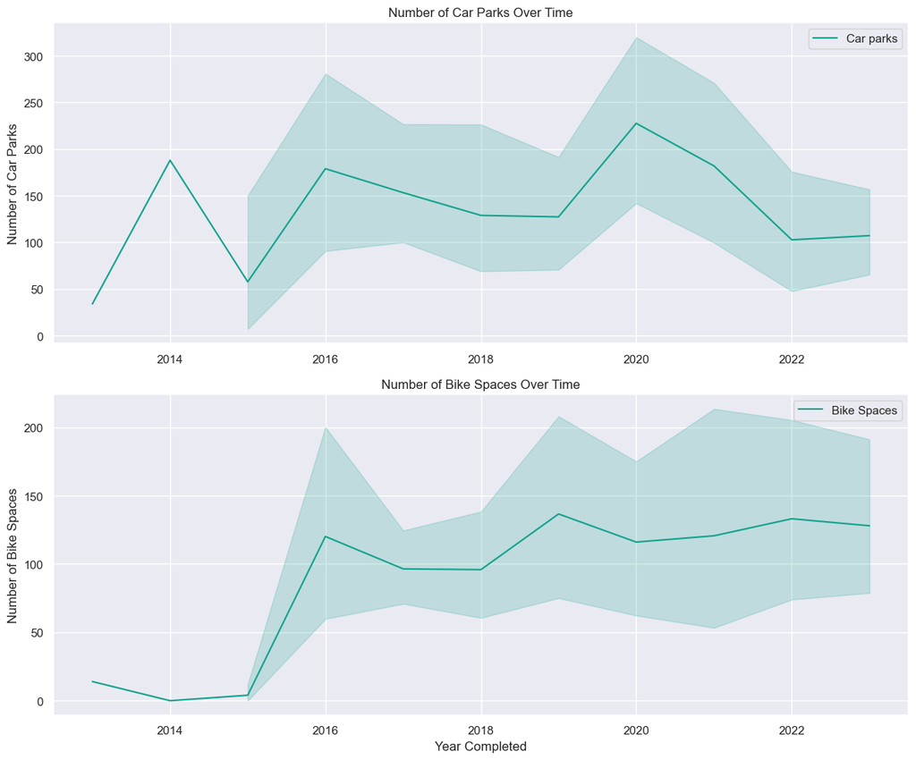

```python
# Car Parks and Bike Spaces
# Filter
selected_land_uses = ['Car parks', 'Bike Spaces']
filtered_data = monitor_footprints[(monitor_footprints['land_use_1'].isin(selected_land_uses)) |
                                   (monitor_footprints['land_use_2'].isin(selected_land_uses)) |
                                   (monitor_footprints['land_use_3'].isin(selected_land_uses))]

# Time
filtered_data['year_completed'] = pd.to_datetime(filtered_data['year_completed'], errors='coerce')
plt.figure(figsize=(12, 10))
sns.set(style='darkgrid')  # Seaborn darkgrid

# Subplots
ax1 = plt.subplot(211)
ax2 = plt.subplot(212)

# Car spaces
sns.lineplot(x='year_completed', y='car_spaces', data=filtered_data, label='Car parks', ax=ax1, color=dark_theme_colors[1])
ax1.set_title('Number of Car Parks Over Time')
ax1.set_xlabel('')
ax1.set_ylabel('Number of Car Parks')
ax1.legend()

# Bike spaces
sns.lineplot(x='year_completed', y='bike_spaces', data=filtered_data, label='Bike Spaces', ax=ax2, color=dark_theme_colors[1])
ax2.set_title('Number of Bike Spaces Over Time')
ax2.set_xlabel('Year Completed')
ax2.set_ylabel('Number of Bike Spaces')
ax2.legend()

# Plot
plt.tight_layout()
plt.show()
```

```python
# Print details
print(filtered_data[['car_spaces', 'bike_spaces']].describe())
```

```
        car_spaces  bike_spaces
count   367.000000   367.000000
mean    118.771117   105.964578
std     167.597446   137.379143
min       0.000000     0.000000
25%       8.000000     9.000000
50%      57.000000    51.000000
75%     163.000000   152.500000
max    1275.000000   786.000000
```

#### Accommodation Yearly Analyses

Development Characteristics: student_accommodation_units, hotel_rooms, serviced_apartments, resi_dwellings

Overall Trends

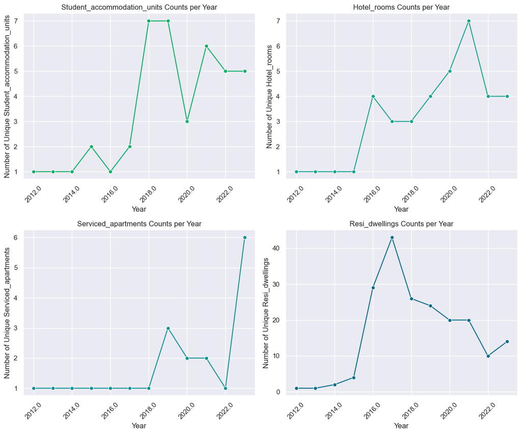

```
       student_accommodation_units  hotel_rooms  serviced_apartments  \
count                    12.000000    12.000000            12.000000
mean                      3.416667     3.166667             1.750000
std                       2.429303     1.898963             1.484771
min                       1.000000     1.000000             1.000000
25%                       1.000000     1.000000             1.000000
50%                       2.500000     3.500000             1.000000
75%                       5.250000     4.000000             2.000000
max                       7.000000     7.000000             6.000000

       resi_dwellings
count       12.000000
mean        16.166667
std         13.224174
min          1.000000
25%          3.500000
50%         17.000000
75%         24.500000
max         43.000000
```

```python
# Accommodation Yearly Analyses
monitor_footprints['year_completed'] = pd.to_datetime(monitor_footprints['year_completed'])

# Accomodation data
accommodation_counts = monitor_footprints.groupby('year_completed').agg({
    'student_accommodation_units': lambda x: len(pd.unique(x.dropna())),
    'hotel_rooms': lambda x: len(pd.unique(x.dropna())),
    'serviced_apartments': lambda x: len(pd.unique(x.dropna())),
    'resi_dwellings': lambda x: len(pd.unique(x.dropna()))
}).reset_index()

# Subplots
fig, axes = plt.subplots(nrows=2, ncols=2, figsize=(12, 10))

# List
columns = ['student_accommodation_units', 'hotel_rooms', 'serviced_apartments', 'resi_dwellings']
colors = dark_theme_colors  # Company colours

# Search data
for i, (col, color) in enumerate(zip(columns, colors)):
    row_index, col_index = divmod(i, 2)
    ax = axes[row_index, col_index]

    # Plot
    sns.lineplot(x=accommodation_counts['year_completed'].dt.year, y=col, data=accommodation_counts, ax=ax, marker='o', linestyle='-', color=color)
    ax.set_title(f'{col.capitalize()} Counts per Year')
    ax.set_xlabel('Year')
    ax.set_ylabel(f'Number of Unique {col.capitalize()}')
    ax.set_xticklabels(ax.get_xticks(), rotation=45)

plt.tight_layout()
plt.show()

# Print details
print(accommodation_counts[['student_accommodation_units', 'hotel_rooms', 'serviced_apartments', 'resi_dwellings']].describe())
```

#### Correlation Analysis Accommodation

Development Characteristics:

- student_accommodation_units
- hotel_rooms
- serviced_apartments
- resi_dwellings

Overall trends

- The wide variability in student accommodation units and residential dwellings suggests that these types of accommodations experience substantial changes over time.
- The lower variability in hotel rooms and serviced apartments may indicate more stable trends in these accommodation types.

Mean

- There is a wide variability in student_accommodation_units data (43.49 mean) with standard deviation (159.34). This indicates significant variations over time caused by potential external influences.
- hotel_rooms (23.40 mean) with standard deviation (81.30), similar results to student__accommodation_units however lower standard deviation implies data is not as dispersed.
- serviced_apartments (3.39 mean) with standard deviation (26.14), there is a lower variablity suggesting more consistency in the number of serviced_apartments then student_accommodation... or hotel_rooms.
- resi_dwellings (127.52 mean) with standard deviation (205.64), there is a higher mean and standard deviation compare to all other accommodation types. This indicates a wider range and more significant variation in the number of residential dwellings.

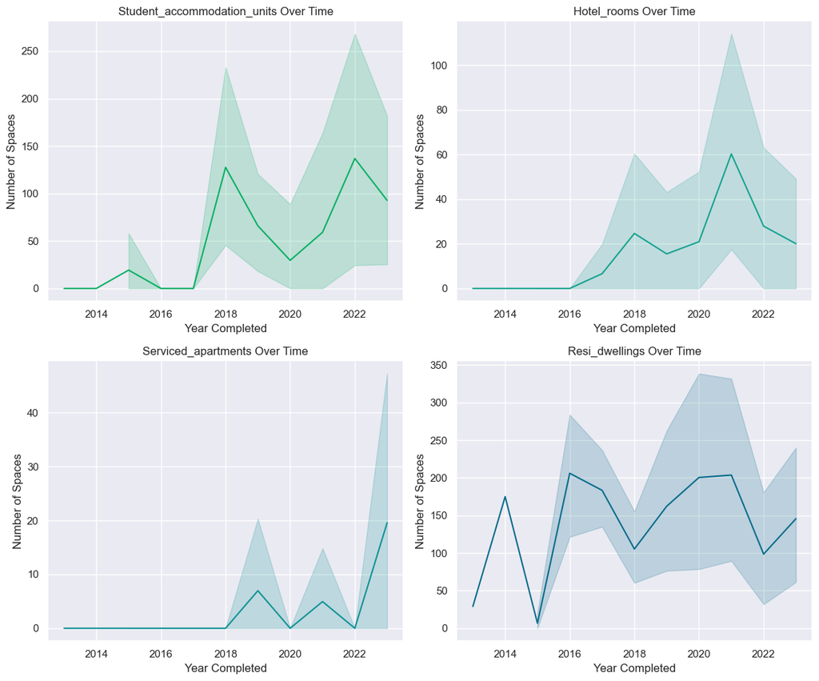

```
Student_accommodation_units: Max 909 spaces in 2021-01-01 00:00:00
Hotel_rooms: Max 687 spaces in NaT
Serviced_apartments: Max 298 spaces in 2023-01-01 00:00:00
Resi_dwellings: Max 1139 spaces in 2019-01-01 00:00:00

Summary Statistics:
   year_completed  num_entries  mean_spaces  max_spaces  min_spaces
0      2013-01-01            1     0.000000           0           0
1      2014-01-01            1     0.000000           0           0
2      2015-01-01            3    19.333333          58           0
3      2016-01-01           21     0.000000           0           0
4      2017-01-01           43     0.000000           0           0
5      2018-01-01           32   127.593750         866           0
6      2019-01-01           32    66.000000         581           0
7      2020-01-01           24    29.583333         710           0
```

[output cut: 36 more lines]

```python
# Accommodation Over Time
# Subplots
fig, axes = plt.subplots(nrows=2, ncols=2, figsize=(12, 10))
columns = ['student_accommodation_units', 'hotel_rooms', 'serviced_apartments', 'resi_dwellings']
colors = dark_theme_colors #Company colours
max_summaries = []  # Data store
summary_stats = pd.DataFrame() # Store data

# Search data
for col, color in zip(columns, colors):
    col_summary = filtered_data.groupby('year_completed').agg(
        num_entries=('year_completed', 'count'),
        mean_spaces=(col, 'mean'),
        max_spaces=(col, 'max'),
        min_spaces=(col, 'min')
    ).reset_index()
    summary_stats = pd.concat([summary_stats, col_summary])

# Iterate through dataset
for i, (col, color) in enumerate(zip(columns, colors)):
    row_index, col_index = divmod(i, 2)
    ax = axes[row_index, col_index]

    # Plot
    sns.lineplot(x='year_completed', y=col, data=filtered_data, ax=ax, color=colors[i])
    ax.set_title(f'{col.capitalize()} Over Time')
    ax.set_xlabel('Year Completed')
    ax.set_ylabel('Number of Spaces')

    # Values & Max Years
    max_year = filtered_data.loc[filtered_data[col].idxmax(), 'year_completed']
    max_spaces = filtered_data.loc[filtered_data[col].idxmax(), col]

    # Summaries
    max_summaries.append(f'{col.capitalize()}: Max {max_spaces} spaces in {max_year}')

plt.tight_layout()
plt.show()

# Summary
for summary in max_summaries:
    print(summary)

# Print summary statistics
print("\nSummary Statistics:")
print(summary_stats)
```

#### User Query

##### Explore all land uses from dataset per year

```python
# land_uses all three
unique_land_uses = set(monitor_footprints['land_use_1'].unique()).union(
    set(monitor_footprints['land_use_2'].unique()),
    set(monitor_footprints['land_use_3'].unique())
)

# Remove NaN
unique_land_uses = [land_use for land_use in unique_land_uses if pd.notna(land_use)]

# User query
@interact(land_use=widgets.Dropdown(options=unique_land_uses, description='Select Land Use:'))
def plot_yearly_distribution(land_use): # Filter
    filtered_dataset = monitor_footprints[
        (monitor_footprints['land_use_1'] == land_use) |
        (monitor_footprints['land_use_2'] == land_use) |
        (monitor_footprints['land_use_3'] == land_use)
    ]

    # Count number per year for the selected land use
    yearly_counts = filtered_dataset['year_completed'].value_counts().sort_index()

    # Plot
    plt.figure(figsize=(10, 6))
    sns.barplot(x=yearly_counts.index, y=yearly_counts.values, color=dark_theme_colors[1])
    plt.xlabel('Year')
    plt.ylabel(f'Number of {land_use} per Year')
    plt.xticks(rotation=45, ha='right')
    plt.title(f'Yearly Distribution of {land_use}')
    plt.show()
```

```
interactive(children=(Dropdown(description='Select Land Use:', options=('Student Accommodation', 'Car parks', …
```

```python
monitor_footprints['year_completed'] = pd.to_datetime(monitor_footprints['year_completed'], errors='coerce').dt.date

# Count unique values for each land_use in each year
land_use_counts = monitor_footprints.groupby('year_completed').agg({
    'land_use_1': lambda x: (x.nunique(), x.dropna().unique().tolist()),
    'land_use_2': lambda x: (x.nunique(), x.dropna().unique().tolist()),
    'land_use_3': lambda x: (x.nunique(), x.dropna().unique().tolist())
}).reset_index()

# Display the counts and land uses
for index, row in land_use_counts.iterrows():
    year = row['year_completed']
    land_use_1_count, land_use_1_list = row['land_use_1']
    land_use_2_count, land_use_2_list = row['land_use_2']
    land_use_3_count, land_use_3_list = row['land_use_3']

    print(f"Year {year}:")
    print(f"Land Use 1 - Count: {land_use_1_count}, Land Uses: {land_use_1_list}")
    print(f"Land Use 2 - Count: {land_use_2_count}, Land Uses: {land_use_2_list}")
    print(f"Land Use 3 - Count: {land_use_3_count}, Land Uses: {land_use_3_list}")
    print("\n")
```

```
Year 2012-01-01:
Land Use 1 - Count: 1, Land Uses: ['Dwellings']
Land Use 2 - Count: 0, Land Uses: []
Land Use 3 - Count: 0, Land Uses: []


Year 2013-01-01:
Land Use 1 - Count: 1, Land Uses: ['Dwellings']
Land Use 2 - Count: 1, Land Uses: ['Car parks']
Land Use 3 - Count: 1, Land Uses: ['Bike Spaces']


Year 2014-01-01:
Land Use 1 - Count: 1, Land Uses: ['Dwellings']
Land Use 2 - Count: 1, Land Uses: ['Car parks']
Land Use 3 - Count: 0, Land Uses: []


Year 2015-01-01:
Land Use 1 - Count: 3, Land Uses: ['Student Accommodation', 'Dwellings', 'Office']
Land Use 2 - Count: 2, Land Uses: ['Car parks', 'Retail']
Land Use 3 - Count: 3, Land Uses: ['Recreation', 'Bike Spaces', 'Car parks']


Year 2016-01-01:
Land Use 1 - Count: 4, Land Uses: ['Hotel rooms', 'Dwellings', 'Industrial', 'Storage']
Land Use 2 - Count: 6, Land Uses: ['Office', 'Car parks', 'Dwellings', 'Retail', 'Bike Spaces', 'Community space']
Land Use 3 - Count: 7, Land Uses: ['Bike Spaces', 'Recreation', 'Hospital', 'Retail', 'Hotel rooms', 'Car parks', 'Office']


Year 2017-01-01:
Land Use 1 - Count: 7, Land Uses: ['Hotel rooms', 'Dwellings', 'Office', 'Childcare places', 'Education', 'Car parks', 'Student Accommodation']
Land Use 2 - Count: 9, Land Uses: ['Car parks', 'Retail', 'Dwellings', 'Recreation', 'Community space', 'Hotel rooms', 'Office', 'Industrial', 'Education']
Land Use 3 - Count: 6, Land Uses: ['Bike Spaces', 'Retail', 'Recreation', 'Office', 'Car parks', 'Dwellings']


Year 2018-01-01:
Land Use 1 - Count: 8, Land Uses: ['Hospital', 'Office', 'Dwellings', 'Student Accommodation', 'Retail', 'Recreation', 'Car parks', 'Hotel rooms']
Land Use 2 - Count: 5, Land Uses: ['Education', 'Car parks', 'Bike Spaces', 'Retail', 'Hotel rooms']
Land Use 3 - Count: 4, Land Uses: ['Car parks', 'Retail', 'Community space', 'Bike Spaces']
```

[output cut: 15 more lines]

```
Land Use 1 - Count: 9, Land Uses: ['Dwellings', 'Hotel rooms', 'Student Accommodation', 'Recreation', 'Car parks', 'Office', 'Retail', 'Education', 'Community space']
Land Use 2 - Count: 9, Land Uses: ['Hotel rooms', 'Bike Spaces', 'Car parks', 'Office', 'Retail', 'Dwellings', 'Serviced apartments', 'Childcare places', 'Education']
Land Use 3 - Count: 9, Land Uses: ['Car parks', 'Retail', 'Office', 'Bike Spaces', 'Dwellings', 'Hospital', 'Recreation', 'Industrial', 'Childcare places']


Year 2022-01-01:
Land Use 1 - Count: 6, Land Uses: ['Industrial', 'Student Accommodation', 'Dwellings', 'Hotel rooms', 'Education', 'Office']
Land Use 2 - Count: 4, Land Uses: ['Office', 'Retail', 'Car parks', 'Bike Spaces']
Land Use 3 - Count: 5, Land Uses: ['Car parks', 'Bike Spaces', 'Retail', 'Office', 'Hotel rooms']


Year 2023-01-01:
Land Use 1 - Count: 7, Land Uses: ['Dwellings', 'Storage', 'Serviced apartments', 'Student Accommodation', 'Office', 'Hotel rooms', 'Education']
Land Use 2 - Count: 6, Land Uses: ['Car parks', 'Office', 'Bike Spaces', 'Retail', 'Childcare places', 'Hotel rooms']
Land Use 3 - Count: 4, Land Uses: ['Retail', 'Bike Spaces', 'Car parks', 'Office']
```

#### Find most common land uses per year

```python
# Find the most used value and unique values in a series
def find_most_used(series):
    if not series.dropna().empty:
        most_used = series.value_counts().idxmax()
        second_most_used = series.value_counts().idxmin() if len(series.value_counts()) > 1 else None
        return most_used, second_most_used
    else:
        return None, None

# Drop rows with missing values in 'year_completed' column
monitor_footprints_date = monitor_footprints.dropna(subset=['year_completed'])
monitor_footprints_date['year_completed'] = pd.to_datetime(monitor_footprints_date['year_completed']).dt.year.astype(int)

# Count
land_use_counts = monitor_footprints_date.groupby('year_completed').agg({
    'land_use_1': lambda x: find_most_used(x),
    'land_use_2': lambda x: find_most_used(x),
    'land_use_3': lambda x: find_most_used(x)
}).reset_index()

# Display
for index, row in land_use_counts.iterrows():
    year = row['year_completed']
    (most_used_land_use_1, second_most_used_land_use_1) = row['land_use_1']
    (most_used_land_use_2, second_most_used_land_use_2) = row['land_use_2']
    (most_used_land_use_3, second_most_used_land_use_3) = row['land_use_3']

    print(f"Year {year}:")
    print(f"Most Used Land Use 1: {most_used_land_use_1}")
    print(f"Second Most Used Land Use 1: {second_most_used_land_use_1}")
    print(f"Most Used Land Use 2: {most_used_land_use_2}")
    print(f"Second Most Used Land Use 2: {second_most_used_land_use_2}")
    print(f"Most Used Land Use 3: {most_used_land_use_3}")
    print(f"Second Most Used Land Use 3: {second_most_used_land_use_3}")
    print("\n")
```

```
Year 2012:
Most Used Land Use 1: Dwellings
Second Most Used Land Use 1: Car parks
Most Used Land Use 2: None
Second Most Used Land Use 2: None
Most Used Land Use 3: None
Second Most Used Land Use 3: None


Year 2013:
Most Used Land Use 1: Dwellings
Second Most Used Land Use 1: Car parks
Most Used Land Use 2: Car parks
Second Most Used Land Use 2: Bike Spaces
Most Used Land Use 3: Bike Spaces
Second Most Used Land Use 3: Car parks


Year 2014:
Most Used Land Use 1: Dwellings
Second Most Used Land Use 1: Car parks
Most Used Land Use 2: Car parks
Second Most Used Land Use 2: Bike Spaces
Most Used Land Use 3: None
Second Most Used Land Use 3: None


Year 2015:
Most Used Land Use 1: Dwellings
Second Most Used Land Use 1: Car parks
Most Used Land Use 2: Car parks
Second Most Used Land Use 2: Bike Spaces
Most Used Land Use 3: Bike Spaces
Second Most Used Land Use 3: Childcare places


Year 2016:
Most Used Land Use 1: Dwellings
Second Most Used Land Use 1: Car parks
Most Used Land Use 2: Car parks
```

[output cut: 51 more lines]

```
Most Used Land Use 1: Dwellings
Second Most Used Land Use 1: Car parks
Most Used Land Use 2: Car parks
Second Most Used Land Use 2: Childcare places
Most Used Land Use 3: Retail
Second Most Used Land Use 3: Childcare places


Year 2023:
Most Used Land Use 1: Dwellings
Second Most Used Land Use 1: Car parks
Most Used Land Use 2: Car parks
Second Most Used Land Use 2: Community space
Most Used Land Use 3: Retail
Second Most Used Land Use 3: Childcare places
```

#### Most common land uses per year

```python
# Find the most used value and unique values in a series
def find_most_used(series):
    if not series.dropna().empty:
        most_used = series.value_counts().idxmax()
        second_most_used = series.value_counts().idxmin() if len(series.value_counts()) > 1 else None
        return most_used, second_most_used
    else:
        return None, None

# Drop rows with missing values in 'year_completed' column
monitor_footprints_date = monitor_footprints.dropna(subset=['year_completed'])
monitor_footprints_date['year_completed'] = pd.to_datetime(monitor_footprints_date['year_completed']).dt.year.astype(int)

# Count
land_use_counts = monitor_footprints_date.groupby('year_completed').agg({
    'land_use_1': lambda x: find_most_used(x),
    'land_use_2': lambda x: find_most_used(x),
    'land_use_3': lambda x: find_most_used(x)
}).reset_index()

# Display
for index, row in land_use_counts.iterrows():
    year = row['year_completed']
    (most_used_land_use_1, second_most_used_land_use_1) = row['land_use_1']
    (most_used_land_use_2, second_most_used_land_use_2) = row['land_use_2']
    (most_used_land_use_3, second_most_used_land_use_3) = row['land_use_3']

    print(f"Year {year}:")
    print(f"Most Used Land Use 1: {most_used_land_use_1}")
    print(f"Second Most Used Land Use 1: {second_most_used_land_use_1}")
    print(f"Most Used Land Use 2: {most_used_land_use_2}")
    print(f"Second Most Used Land Use 2: {second_most_used_land_use_2}")
    print(f"Most Used Land Use 3: {most_used_land_use_3}")
    print(f"Second Most Used Land Use 3: {second_most_used_land_use_3}")
    print("\n")
```

```
Year 2012:
Most Used Land Use 1: Dwellings
Second Most Used Land Use 1: Car parks
Most Used Land Use 2: None
Second Most Used Land Use 2: None
Most Used Land Use 3: None
Second Most Used Land Use 3: None


Year 2013:
Most Used Land Use 1: Dwellings
Second Most Used Land Use 1: Car parks
Most Used Land Use 2: Car parks
Second Most Used Land Use 2: Bike Spaces
Most Used Land Use 3: Bike Spaces
Second Most Used Land Use 3: Car parks


Year 2014:
Most Used Land Use 1: Dwellings
Second Most Used Land Use 1: Car parks
Most Used Land Use 2: Car parks
Second Most Used Land Use 2: Bike Spaces
Most Used Land Use 3: None
Second Most Used Land Use 3: None


Year 2015:
Most Used Land Use 1: Dwellings
Second Most Used Land Use 1: Car parks
Most Used Land Use 2: Car parks
Second Most Used Land Use 2: Bike Spaces
Most Used Land Use 3: Bike Spaces
Second Most Used Land Use 3: Childcare places


Year 2016:
Most Used Land Use 1: Dwellings
Second Most Used Land Use 1: Car parks
Most Used Land Use 2: Car parks
```

[output cut: 51 more lines]

```
Most Used Land Use 1: Dwellings
Second Most Used Land Use 1: Car parks
Most Used Land Use 2: Car parks
Second Most Used Land Use 2: Childcare places
Most Used Land Use 3: Retail
Second Most Used Land Use 3: Childcare places


Year 2023:
Most Used Land Use 1: Dwellings
Second Most Used Land Use 1: Car parks
Most Used Land Use 2: Car parks
Second Most Used Land Use 2: Community space
Most Used Land Use 3: Retail
Second Most Used Land Use 3: Childcare places
```

#### Facilitate Strategic Traffic Management & Recommondations

100m radius around Traffic managment sites to show potentially impacted streets for public.

1. Install alternative paths and crosswalks within identified locations
2. Develop dedicated bike lanes within radius areas to support safe cycling.
3. Implement signage within 100m radius to support public awareness of traffic management/ construction.
4. Introduce speed bumps, raised crosswalks and slow cars down in the radius area.
5. Review impacted Public Transport Stops within radius with dedicates lanes for priority.
6. Implement parking solutions within radius to support public for duration of Traffic Management/ construction.
7. Ensure emergency vehicles have access during peak hours within radius zone.

```python
# radius (500m) a visual aid/ does not represent actual road distances.

melbourne_coordinates = [-37.814, 144.96332]

# Folium map centered on Melbourne
m = folium.Map(location=melbourne_coordinates, zoom_start=16)

# Filter activities with classification "Traffic Management"
traffic_management_activities = activities[activities['classification'] == 'Traffic Management']

# Print unique classifications
unique_classifications = traffic_management_activities['classification'].unique()
print("Unique Classifications in Traffic Management Activities:")
print(unique_classifications)

# Traffic management activities
for _, row in traffic_management_activities.iterrows():
    lat, lng = row['latitude'], row['longitude']

    # Add a marker for each traffic management activity
    folium.Marker(
        location=[lat, lng],
        popup=row['classification'],
        icon=folium.Icon(color='green', icon='glyphicon-wrench')
    ).add_to(m)

    # Add 100m radius
    folium.Circle(
        location=[lat, lng],
        radius=100,
        color='red',
        fill=True,
        fill_opacity=0.2
    ).add_to(m)

print("Traffic Management Activities in Dataset")
# Display the map
m
```

```
Unique Classifications in Traffic Management Activities:
['Traffic Management']
Traffic Management Activities in Dataset
```

Make this Notebook Trusted to load map: File -> Trust Notebook

[interactive chart not shown]

#### Areas of High Concentration Traffic Management

```python
# spatial analysis
m = folium.Map(location=[-37.814, 144.96332], zoom_start=12)

# Heatmap concentration of traffic management activities
HeatMap(traffic_management_activities[['latitude', 'longitude']]).add_to(m)
m
```

Make this Notebook Trusted to load map: File -> Trust Notebook

[interactive chart not shown]

#### Duration of Traffic Management

Overall Traffic Management Trends

- Min Duration (1 day)
- Max Duration (1344 days)
- Mean Duration (178 days)
- Median Duration (171 days)
- 2022 data shows a relatively short duration range, with most activities *between 161 and 171 days*. The distribution is relatively tight (close mean and median).
- 2021 data has a longer duration range *217 to 241 days*. The mean and median durations are close, suggesting a relatively symmetrical distribution.
- 2019 data indicates that all activities have the same duration of 1344 days. This could be a placeholder value or may represent a specific type of long-term traffic management activity.

Overall, duration patterns of traffic management activities in different years may have potential outliers causing the uniform duration in 2019. Further investigation into the specific activities and context is recommended.

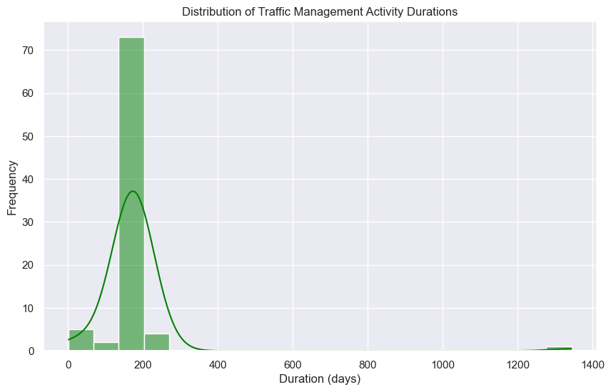

```python
# duration analysis
plt.figure(figsize=(10, 6))
sns.histplot(traffic_management_activities['duration'], bins=20, kde=True, color='green')
plt.title('Distribution of Traffic Management Activity Durations')
plt.xlabel('Duration (days)')
plt.ylabel('Frequency')
plt.show()
```

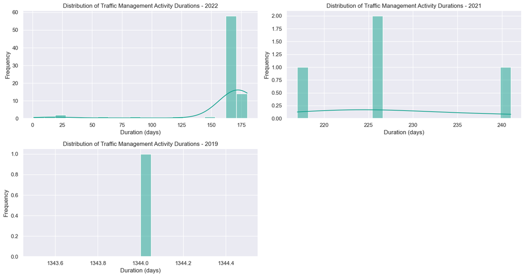

```
Summary for 2022:
Min Duration: 1.00 days
Max Duration: 180.00 days
Mean Duration: 161.30 days
Median Duration: 171.00 days

Summary for 2021:
Min Duration: 217.00 days
Max Duration: 241.00 days
Mean Duration: 227.50 days
Median Duration: 226.00 days

Summary for 2019:
Min Duration: 1344.00 days
Max Duration: 1344.00 days
Mean Duration: 1344.00 days
Median Duration: 1344.00 days
```

```python
# Duration
traffic_management_activities = activities[activities['classification'] == 'Traffic Management']
traffic_management_activities['start_date'] = pd.to_datetime(traffic_management_activities['start_date'])
traffic_management_activities['end_date'] = pd.to_datetime(traffic_management_activities['end_date'])
traffic_management_activities['year'] = traffic_management_activities['start_date'].dt.year

unique_years = traffic_management_activities['year'].unique()
num_years = len(unique_years)
colors = dark_theme_colors[1]  # Company colours
num_cols = 2
num_rows = (num_years + num_cols - 1) // num_cols

plt.figure(figsize=(15, 8))

for i, year in enumerate(unique_years):
    plt.subplot(num_rows, num_cols, i + 1)
    sns.histplot(
        traffic_management_activities[traffic_management_activities['year'] == year]['duration'],
        bins=20, kde=True, color=colors
    )
    plt.title(f'Distribution of Traffic Management Activity Durations - {year}')
    plt.xlabel('Duration (days)')
    plt.ylabel('Frequency')

plt.tight_layout()
plt.show()

# Summary
for year in unique_years:
    # Each year
    min_duration = np.min(traffic_management_activities[traffic_management_activities['year'] == year]['duration'])
    max_duration = np.max(traffic_management_activities[traffic_management_activities['year'] == year]['duration'])
    mean_duration = np.mean(traffic_management_activities[traffic_management_activities['year'] == year]['duration'])
    median_duration = np.median(traffic_management_activities[traffic_management_activities['year'] == year]['duration'])

    # Print
    print(f'\nSummary for {year}:')
    print(f'Min Duration: {min_duration:.2f} days')
    print(f'Max Duration: {max_duration:.2f} days')
    print(f'Mean Duration: {mean_duration:.2f} days')
    print(f'Median Duration: {median_duration:.2f} days')
```

#### Estimate impact of Traffic Management on population

*Note: Data for Traffic Management* 2019: There is 1 recorded activity. 2021: There are 4 recorded activities. 2022: The majority of activities, with 80 recorded events.

- 2019, 1 recorded activity.
- 2021, 4 recorded activities.
- 2022, majority of activities, 80 recorded events.

```python
# Impact on public
# Filter
traffic_management_activities = activities[activities['classification'] == 'Traffic Management']

# Store the estimated number of people affected
activities['estimated_people_affected'] = 0

# Euclidean two points
def euclidean_distance(lat1, lon1, lat2, lon2):
    return np.sqrt((lat1 - lat2)**2 + (lon1 - lon2)**2)

# Traffic management activity
for _, activity_row in traffic_management_activities.iterrows():
    # monitor footprint
    for _, footprint_row in monitor_footprints.iterrows():
        # Euclidean distance
        distance = euclidean_distance(
            activity_row['latitude'], activity_row['longitude'],
            footprint_row['latitude_footprints'], footprint_row['longitude_footprints']
        )

        estimated_people_affected = distance * 50  # 100m est

        # Update est people affected
        activities.loc[activities['activity_id'] == activity_row['activity_id'], 'estimated_people_affected'] += estimated_people_affected
print(activities[['activity_id', 'classification', 'estimated_people_affected']])
```

```
                                           activity_id      classification  \
0    SS-1112882-0-104568-ESP-Referred to ESG-240520...          Structures
1    SS-1078568-0-103627-EGA-Permit Issued-07082021...          Structures
2    WO-721357-1445540-1445540-61-Closed-1001202200...  Traffic Management
3    SS-1079739-0-593729-EGA-Permit Issued-18082021...          Structures
4    SS-1114327-0-101142-EGA-Permit Issued-01052022...          Structures
..                                                 ...                 ...
599  RP-59095-193964-21212-COU-Confirmed-1505202200...    Reserved Parking
600  P-6954-4055-4055-9-Provisional-240720220000-24...        Public Event
601  RP-59031-193430-20009-COU-Confirmed-1405202200...    Reserved Parking
602  RP-59102-194038-21553-BUS-Confirmed-2605202200...    Reserved Parking
604  P-7743-4209-4209-5-Provisional Multiple-221220...               Event

     estimated_people_affected
0                     0.000000
1                     0.000000
2                   483.421682
3                     0.000000
4                     0.000000
..                         ...
599                   0.000000
600                   0.000000
601                   0.000000
602                   0.000000
604                   0.000000

[601 rows x 3 columns]
```

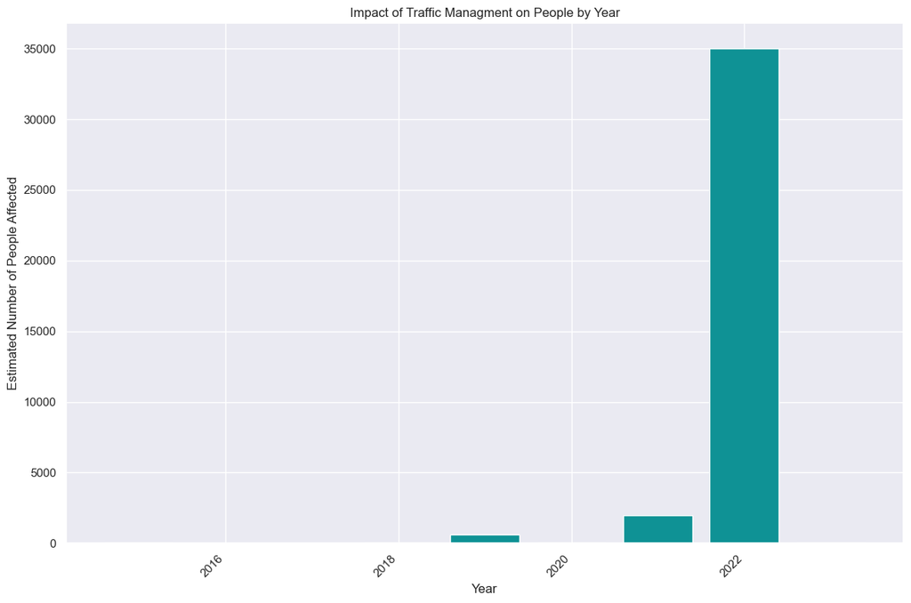

```
Summary:
Total Activities: 601
Total Estimated People Affected: 37587.51393282422
Average People Affected per Activity: 5369.64
```

```python
# Estimated people affected
grouped_activities = activities.groupby(activities['start_date'].dt.year)['estimated_people_affected'].sum()

colors = dark_theme_colors[2]  # Company colours
plt.figure(figsize=(12, 8))
plt.bar(grouped_activities.index, grouped_activities, color=colors)
plt.title('Impact of Traffic Managment on People by Year')
plt.xlabel('Year')
plt.ylabel('Estimated Number of People Affected')
plt.xticks(rotation=45, ha='right')
plt.tight_layout()
plt.show()

# Summary
summary = (
    f"Summary:\n"
    f"Total Activities: {len(activities)}\n"
    f"Total Estimated People Affected: {grouped_activities.sum()}\n"
    f"Average People Affected per Activity: {grouped_activities.mean():.2f}"
)
print(summary)
```

```python
# Datetime
activities['start_date'] = pd.to_datetime(activities['start_date'])
activities['year'] = activities['start_date'].dt.year

# Filter
traffic_management_activities = activities[activities['classification'] == 'Traffic Management']

# Group
grouped_activities_by_year = traffic_management_activities.groupby('year').size()

# Summary
for year, count in grouped_activities_by_year.iteritems():
    print(f"Year: {year}, Traffic Management Activities: {count}")
```

```
Year: 2019, Traffic Management Activities: 1
Year: 2021, Traffic Management Activities: 4
Year: 2022, Traffic Management Activities: 80
```

```python
# Filter 2022
traffic_management_2022 = activities[(activities['classification'] == 'Traffic Management') & (activities['start_date'].dt.year == 2022)]
impact_2022 = traffic_management_2022['estimated_people_affected'].sum()
summary = f"Summary for Traffic Management in 2022:\nTotal Estimated People Affected: {impact_2022}\n"
print(summary)
```

```
Summary for Traffic Management in 2022:
Total Estimated People Affected: 35029.82679402421
```